# SEP Analysis

Adam Edwards

November 12, 2018

## R Code

First, we need to load the data into R and create a data frame.

```r
data <- read.csv("data/fall1998_edge_list.txt", header = TRUE)
as.data.frame(data)
```

```
##                            source                        target
## 1                       bosanquet                       bradley
## 2                       bosanquet                    liberalism
## 3                         bradley                     bosanquet
## 4                         bradley                         frege
## 5                         bradley                       russell
## 6                         bradley                truth-identity
## 7               causation-process                       russell
## 8         causation-probabilistic             causation-process
## 9                   church-turing                turing-machine
## 10                          color                        qualia
## 11                  connectionism              language-thought
## 12           consciousness-animal                        qualia
## 13  contractarianism-contemporary          justification-public
## 14  contractarianism-contemporary                    liberalism
```

[output cut: 125 more lines]

Once the data is loaded, we can create an “igraph” object. We also want to create an edge weight of 1 for each link so that we can combine multiple links into linearly weighted edges. The `simplify` function will also eliminate self-loops.

```r
g <- graph_from_data_frame(as.data.frame(data), directed = TRUE)
E(g)$weight <- 1
g <- simplify(g, edge.attr.comb=list(weight="sum"))
```

The igraph package has several functions that allow us to compute vertex-level and edge-level attributes for the graph. For now, we’ll add node labels, degree, betweenness, and group membership using the `cluster_walktrap` function to assign group membership based on short, randow walks around the graph

We can see the graph object with these new properties and the communities that the clustering algorithm has identified. One interesting feature of this data set is how the clustering algorithm identifies what I take to be the major areas that professional philosophers identify as subfields. There’s no expert knowledge applied to these graphs; it’s an emergent feature of how the SEP is organized.

```r
g
```

```
## IGRAPH eee331c DNW- 60 108 --
## + attr: name (v/c), label (v/c), degree (v/n), betweenness (v/n),
## | group (v/n), weight (e/n)
## + edges from eee331c (vertex names):
##  [1] bosanquet              ->bradley
##  [2] bosanquet              ->liberalism
##  [3] bradley                ->bosanquet
##  [4] bradley                ->frege
##  [5] bradley                ->russell
##  [6] bradley                ->truth-identity
##  [7] causation-process      ->russell
## + ... omitted several edges
```

```r
communities(cluster_walktrap(g))
```

```
## $`1`
## [1] "logic-paraconsistent"     "logic-relevance"
## [3] "mathematics-inconsistent" "sorites-paradox"
## [5] "vagueness"
##
## $`2`
## [1] "kierkegaard"           "ontological-arguments" "hegel"
##
## $`3`
## [1] "bosanquet"          "bradley"            "truth-coherence"
## [4] "truth-identity"     "truth-revision"     "truth-deflationary"
##
## $`4`
## [1] "contractarianism-contemporary" "descartes-epistemology"
## [3] "justice-distributive"          "justification-public"
## [5] "liberalism"                    "maritain"
## [7] "original-position"
##
## $`5`
##  [1] "existence"               "frege"
##  [3] "frege-logic"             "logical-construction"
##  [5] "principia-mathematica"   "private-language"
##  [7] "propositions-singular"   "propositions-structured"
##  [9] "russell"                 "russell-paradox"
## [11] "tropes"                  "whitehead"
##
## $`6`
## [1] "cosmology-theology" "pantheism"
##
## $`7`
## [1] "causation-process"       "causation-probabilistic"
## [3] "spacetime-convensimul"
##
## $`8`
## [1] "feyerabend" "popper"     "nietzsche"
##
## $`9`
## [1] "connectionism"     "language-thought"  "cognitive-science"
## [4] "mental-imagery"
##
## $`10`
## [1] "color"                "consciousness-animal" "qualia"
##
## $`11`
## [1] "church-turing"  "turing-machine"
##
## $`12`
## [1] "folkpsych-simulation" "folkpsych-theory"     "sellars"
##
## $`13`
## [1] "miracles"              "religion-epistemology" "pascal-wager"
##
## $`14`
## [1] "game-theory"      "prisoner-dilemma"
##
## $`15`
## [1] "skepticism-ancient" "stoicism"
```

## Some Charts

We can do some pre-analysis of the graph by looking at the distributions of the different properties:

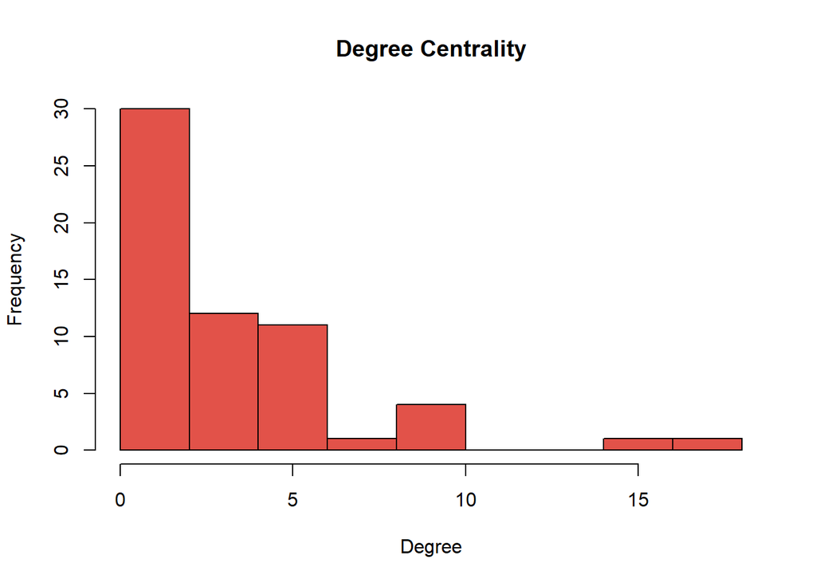

```
##  [1] "bradley"               "bradley"
##  [3] "bradley"               "whitehead"
##  [5] "liberalism"            "liberalism"
##  [7] "principia-mathematica" "principia-mathematica"
##  [9] "frege"                 "russell"
```

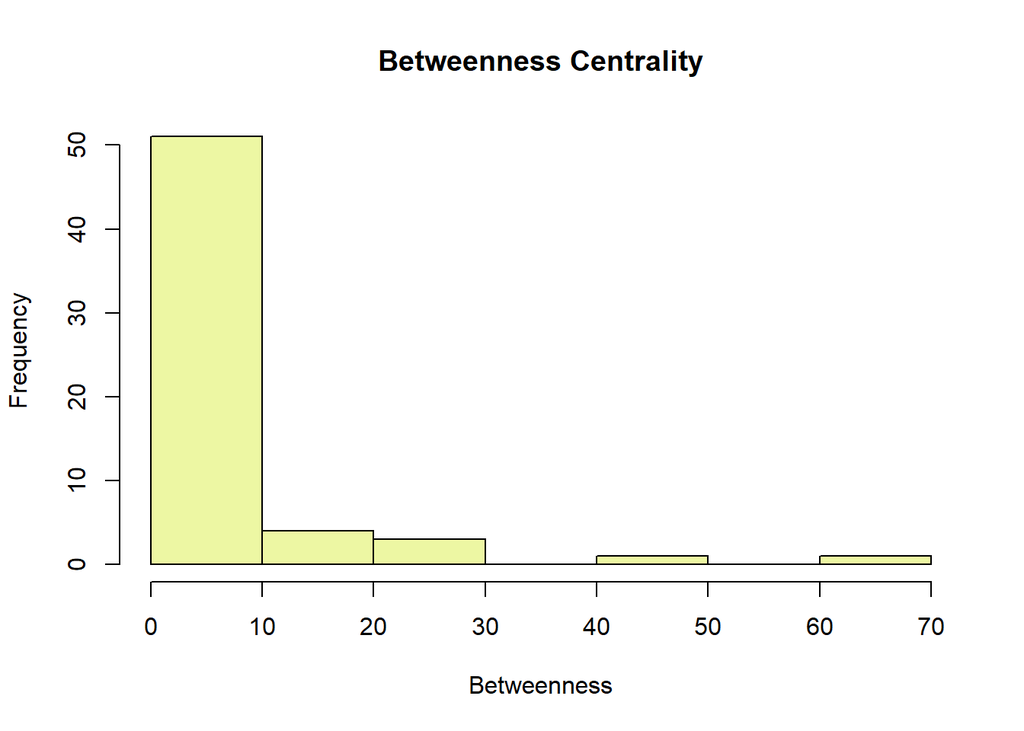

```
##  [1] "russell-paradox"               "contractarianism-contemporary"
##  [3] "feyerabend"                    "causation-process"
##  [5] "bosanquet"                     "truth-identity"
##  [7] "bradley"                       "liberalism"
##  [9] "frege"                         "russell"
```

## Visualizations

With igraph

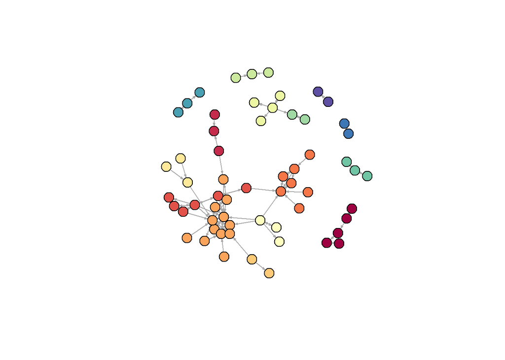

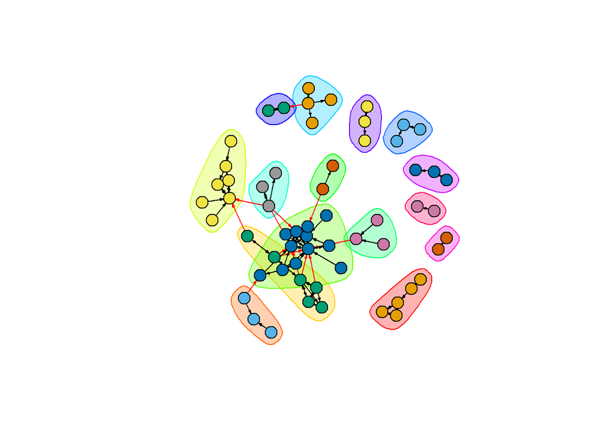

With NetworkD3

[interactive chart not shown]

With visNetwork

[interactive chart not shown]

## References/Acknowledgements

Ognyanova, K. (2018) Network visualization with R. Retrieved from www.kateto.net/network-visualization.